# Week 4: Generalized Linear Models

PS 818 - Statistical Models

Anton Strezhnev

strezhnev@wisc.edu

University of Wisconsin-Madison

September 22, 2025

$$\require{cancel}
\DeclareMathOperator*{\argmin}{arg\,min}$$

$$\DeclareMathOperator*{\argmax}{arg\,max}$$

# Previously

- **Likelihood**: $\mathcal{L}(\theta| \mathbf{Y}) \propto f(\mathbf{Y}| \theta)$
  - Function of $\theta$ (not itself a probability density)
  - Comparisons of likelihoods across different parameters capture notions of model “fit”

    $$\lambda(\theta_1, \theta_2) = \frac{\mathcal{L}(\theta_1 | \mathbf{Y})}{\mathcal{L}(\theta_2 | \mathbf{Y})}$$
- **Frequentist** inference: Use the likelihood to find a “good” estimator for $\theta_0$: the MLE $\hat{\theta}$
  - $\hat{\theta}$ is consistent for $\theta_0$
  - It’s asymptotically normal
  - Its (asymptotic) variance is the inverse Fisher Information

# This week

- **Generalized linear models**
  - What happens when $\mathbb{E}[Y_i|X_i] \neq X_i^{\prime}\beta$?
  - Can we retain the linear form but relate it to a function of the CEF?
- **Types of GLMs**
  - Binary outcome models (e.g. logistic)
  - Ordinal/Multinomial outcome models
  - Count outcome models (e.g. Poisson)
  - Duration models (e.g. exponential)
- **Inference on transformations**
  - “Delta method”
- **Optimization**
  - How does numerical optimization work?
  - **Newton-Raphson** method

# Intro to GLMs

# Motivation: Propensity Scores

# Generalized Linear Models

- Generalized linear models (GLMs) have three components:
  1. A parametric distribution on $Y_i|X_i$ (“stochastic component”)
  2. A linear predictor: $\eta_i = X_i^{\prime}\beta = \beta_0 + \beta_1X_{i1} + \beta_2X_{i2} + \dotsc \beta_kX_{ik}$ (“systematic component”)
  3. A link function $g()$ applied to the CEF $E[Y_i|X_i]$ that yields the linear predictor

     $$g(E[Y_i | X_i]) = \eta_i$$
  - Alternatively, we can write the CEF in terms of the “inverse-link” $g^{-1}()$ applied to the linear predictor

    $$E[Y_i | X_i] = g^{-1}(\eta_i)$$

# Exponential Family

- The types of probability distributions permitted on $Y_i$ are quite general: the **exponential family**
  - This contains the **normal** as well as many other common distributions like the bernoulli, Poisson, exponential, etc…
- Exponential family distributions have density functions of the form

  $$f(y|\theta) = h(y) \exp\bigg\{b(\theta) \cdot T(y) - A(\theta)\bigg\}$$
- $h(y)$, $A(\theta)$, $\eta(\theta)$ and $T(y)$ are known functions
- **The key intuition**: exponential distributions factorize in a convenient way
  - if $b(\theta) = \theta$, then the distribution is in “canonical” form

# Example: Bernoulli

- Consider the bernoulli PMF

  $$P(y_i|\pi_i) = \pi_i^{y_i}(1-\pi_i)^{1-y_i}$$
- Take the log, then the exponent

  $$P(y_i|\pi_i) = \exp\bigg\{\log\bigg[\pi_i^{y_i}(1-\pi_i)^{1-y_i}\bigg]\bigg\}$$
- Properties of logs

  $$P(y_i|\pi_i) = \exp\bigg\{y_i\log(\pi_i) + (1-y_i)\log(1-\pi_i)\bigg\}$$

# Example: Bernoulli

- Rearranging and using properties of logs again

  $$P(y_i|\pi_i) = \exp\bigg\{y_i\log\bigg(\frac{\pi_i}{1-\pi_i}\bigg) + \log(1-\pi_i)\bigg\}$$
- So our exponential form is
  - $h(y) = 1$
  - $T(y) = y_i$
  - $A(\theta) = \log(1-\pi_i)$
  - $b(\theta) = \log\bigg(\frac{\pi_i}{1-\pi_i}\bigg)$
- Critically, this is where we get a good link function
  - The “canonical parameter” is $\log\bigg(\frac{\pi}{1-\pi}\bigg)$.
  - The “canonical link” is the function that equates this parameter with the linear predictor $X_i^{\prime}\beta = \log\bigg(\frac{\pi_i}{1-\pi_i}\bigg)$

# Logistic regression

- The “logit” or “logistic” GLM models the **log-odds** of a binary outcome as a function of the linear predictor $X_i^{\prime}\beta$

  $$Y_i \underset{\text{i.i.d}}{\sim} \text{Bernoulli}(\pi_i)$$

  $$E[Y_i | X_i] = Pr(Y_i = 1 | X_i) = \pi_i$$

  $$\log\bigg(\frac{\pi_i}{1-\pi_i}\bigg) = X_i^{\prime}\beta$$
- Alternatively, this is written in terms of the “inverse-link” function (the logistic function) that relates $\pi_i$ to $g^{-1}(X_i^{\prime}\beta)$

  $$\pi_i = \frac{\exp(X_i^{\prime}\beta)}{1 + \exp(X_i^{\prime}\beta)} = \frac{1}{1 + \exp(-X_i^{\prime}\beta)}$$

# Inverse-link functions

- The logistic function maps inputs on $\mathbb{R}$ to $(0, 1)$

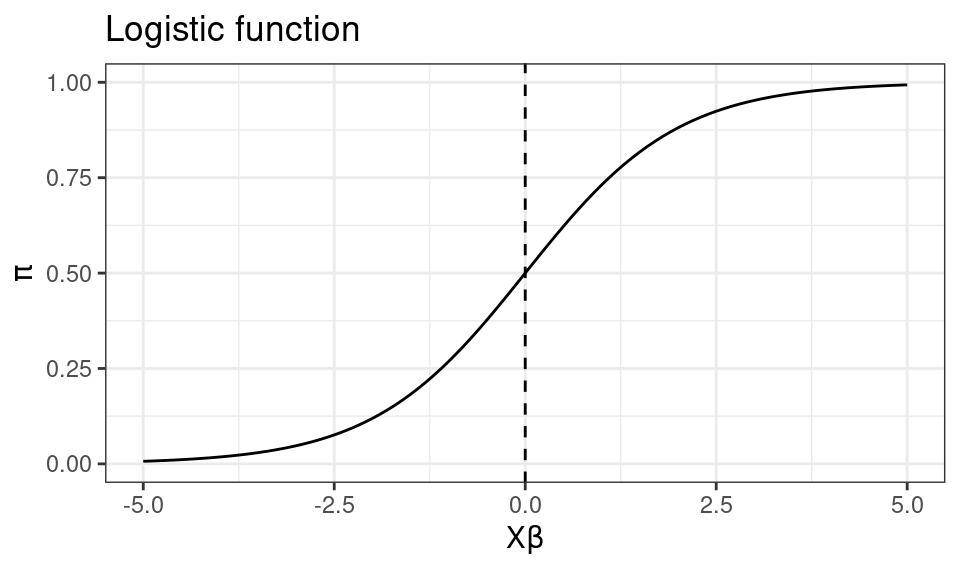

# Inverse-link functions

- Another link is the “probit” whose inverse link is the Normal CDF

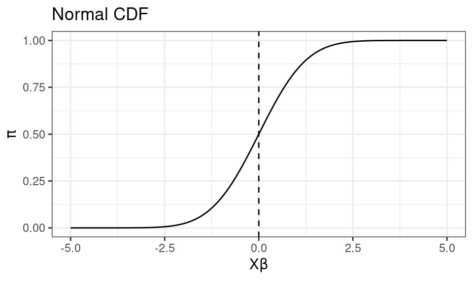

# Inverse-link functions

- When do we use probit vs. logit?
  - Computational convenience!
  - Probit has some good properties for Bayesian inference
- Can you tell the difference?

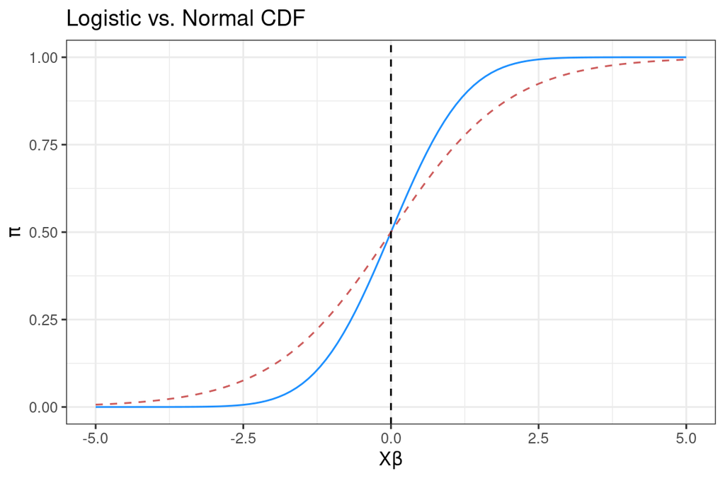

# Estimation

- We obtain an estimate of $\beta$, $\hat{\beta}$ using maximum likelihood.
- Our MLE estimator is:

  $$\hat{\beta} = \argmax_\beta \ \log f(\mathbf{y} | \beta, \mathbf{X})$$
- Recall our score function is:

  $$S(\beta) = \nabla \log f(\mathbf{y} | \beta, \mathbf{X}) = \begin{bmatrix} \frac{\partial}{\partial \beta_0} \log f(\mathbf{y} | \beta, \mathbf{X}) \\
  \frac{\partial}{\partial \beta_1} \log f(\mathbf{y} | \beta, \mathbf{X}) \\
  \vdots \\
  \frac{\partial}{\partial \beta_k} \log f(\mathbf{y} | \beta, \mathbf{X}) \end{bmatrix}$$
- The likelihood is convex, so finding the maximum equates to solving for the value of $\beta$ that sets $S(\beta) = 0$
  - A common numerical method is **Newton-Raphson**

# Newton-Raphson

- An iterative algorithm starts at some initial guess $\hat{\beta}^{(0)}$
- Let $\hat{\beta}^{(t)}$ denote the “current” value of $\hat{\beta}$ and $\hat{\beta}^{(t+1)}$ our update – we keep iterating until convergence.
- Our goal is to solve for a zero of $S(\beta)$
  - Let’s do a first-order Taylor approximation around our current guess $S(\hat{\beta}^{(t)})$

  $$S(\beta) \approx S(\hat{\beta}^{(t)}) + \nabla S(\hat{\beta}^{(t)}) \left(\beta - \hat{\beta}^{(t)}\right)$$
- What’s $\nabla S(\hat{\beta}^{(t)})$?
  - It’s the Jacobian of the gradient…or the matrix of second-order partial derivatives of the log-likelihood…or the Hessian!
  - Denote it $\mathbf{H}(\hat{\beta}^{(t)})$

# Newton-Raphson

- Our next value of $\hat{\beta}$ is the value of $\beta$ that sets the score equal to zero

  $$0 = S(\hat{\beta}^{(t)}) + \mathbf{H}(\hat{\beta}^{(t)}) \left(\hat{\beta}^{(t+1)} - \hat{\beta}^{(t)}\right)$$
- Multiply through by the inverse hessian

  $$\hat{\beta}^{(t+1)} = \hat{\beta}^{(t)} - \mathbf{H}^{-1}(\hat{\beta}^{(t)}) S(\hat{\beta}^{(t)})$$
- Recall that the negative inverse hessian is also the **Observed Fisher Information**
  - An alternative algorithm, **Fisher Scoring** substitutes this for the expected Fisher Information
- All of these and more are implemented in the `maxLik` R package!

# Gradient ascent

- Compare the Newton-Raphson updates to the classic “gradient descent/gradient ascent” algorithm

  $$\hat{\beta}^{(t+1)} = \hat{\beta}^{(t)} + \eta_t S(\hat{\beta}^{(t)})$$
- Gradient ascent chooses some sequence of $\eta_t$ (the ‘learning rate’ or ‘step size’) at iteration $t$
  - Gradient tells us **which direction** to move in and $\eta_t$ tells us **how much to move**
- Contrast with Newton-Raphson where “how much to move” is based on calculating and invert the Hessian (computationally expensive!)

# Deriving a logit likelihood

- From our logit link function, we have

  $$\log\left(\frac{\pi}{1-\pi}\right) = X_i^{\prime}\beta$$

and

$$1 - \pi_i = 1 - \frac{1}{1 + \exp(-X_i^{\prime}\beta)} = \frac{\exp(-X_i^{\prime}\beta)}{1 + \exp(-X_i^{\prime}\beta)} = \frac{1}{1 + \exp(X_i^{\prime}\beta)}$$

- Let’s write the log-likelihood:

  $$\ell(\beta | \mathbf{y}, \mathbf{X}) = \sum_{i=1}^Ny_i X_i^{\prime}\beta + \log\bigg(\frac{1}{1 + \exp(X_i^{\prime}\beta)}\bigg)$$

  $$\ell(\beta | \mathbf{y}, \mathbf{X}) = \sum_{i=1}^Ny_i X_i^{\prime}\beta - \log\bigg(1 + \exp(X_i^{\prime}\beta)\bigg)$$

# Iteratively reweighted least squares

- For GLMs with the canonical link, the Newton-Raphson updates can also be written as a series of solutions to a *weighted least squares* problem.
- Take our Bernoulli likelihood:

$$\ell(\mathbf{Y} | \mathbf{X}, \beta) = \sum_{i=1}^n y_iX_i^\prime\beta - \log\bigg(1 + \exp(X_i^\prime\beta)\bigg)$$

- Take the first order derivative w.r.t $\beta$ to get the score (remember, we typically let $X_{i0} = 1$ be the intercept)

  $$S(\beta) = \begin{bmatrix} \sum_{i=1}^n y_i - \frac{\exp(X_i^\prime \beta)}{1 + \exp(X_i^\prime \beta)} \\
  \sum_{i=1}^n y_iX_{i1} - X_{i1}\frac{\exp(X_i^\prime \beta)}{1 + \exp(X_i^\prime \beta)} \\
  \vdots \\
  \sum_{i=1}^n y_iX_{ik} - X_{ik}\frac{\exp(X_i^\prime \beta)}{1 + \exp(X_i^\prime \beta)} \end{bmatrix}$$

# Iteratively reweighted least squares

- Writing this in matrix form and substituting our definition of $\pi_i = \frac{\exp(X_i^\prime \beta)}{1 + \exp(X_i^\prime \beta)}$

$$S(\beta) = \sum_{i=1}^n X_i(y_i - \pi_i) = \mathbf{X}^\prime (y - \pi)$$

# Iteratively reweighted least squares

- Differentiating the score again to get the Hessian
  - First, the diagonal terms:

$$\frac{\partial^2}{\partial \beta_k^2}\ell(\mathbf{Y} | \mathbf{X}, \beta) = - \sum_{i=1}^n X_{ik} \bigg(X_{ik} \frac{\exp(X_i^\prime \beta)}{1 + \exp(X_i^\prime\beta)} - X_{ik} \frac{\exp(X_i^\prime \beta)^2}{(1 + \exp(X_i^\prime\beta))^2 }\bigg)$$

- Factoring and substituting in $\pi$ again

$$\frac{\partial^2}{\partial \beta_k^2}\ell(\mathbf{Y} | \mathbf{X}, \beta) = -\sum_{i=1}^n X_{ik}^2(\pi_i - \pi_i^2) = -\sum_{i=1}^n X_{ik}^2\bigg[\pi_i(1 - \pi_i)\bigg]$$

- The off-diagonal terms also have this $\pi(1-\pi)$ component:

$$\frac{\partial^2}{\partial \beta_k \partial \beta_j}\ell(\mathbf{Y} | \mathbf{X}, \beta) = -\sum_{i=1}^n X_{ik}X_{ij}\bigg[\pi_i(1 - \pi_i)\bigg]$$

# Iteratively reweighted least squares

- In matrix form, our Hessian is

$$\mathbf{H}(\beta) = -\mathbf{X}^\prime\mathbf{W}\mathbf{X}$$
where $\mathbf{W}$ is an $n \times n$ diagonal matrix with elements $\pi_i(1-\pi_i)$

- Plugging these two components into our Newton-Raphson update formula

$$\hat{\beta}^{(t+1)} = \hat{\beta}^{(t)} - \mathbf{H}^{-1}(\hat{\beta}^{(t)}) S(\hat{\beta}^{(t)})$$
$$\hat{\beta}^{(t+1)} = \hat{\beta}^{(t)} + (\mathbf{X}^\prime\mathbf{W}\mathbf{X})^{-1}\mathbf{X}^\prime (y - \pi^{(t)})$$
where the elements of $\mathbf{W}$ are evaluated at $\pi^{(t)}$ (the “predicted probabilities” at step $t$).

- Re-arranging yields an update step that has the form of a weighted least squares regression with an augmented outcome based on the “current” parameters $\hat{\beta}^{(t)}$ and $\pi^{(t)}$

$$\hat{\beta}^{(t+1)} = (\mathbf{X}^\prime\mathbf{W}\mathbf{X})^{-1}\mathbf{X}^\prime \mathbf{W}\bigg(\mathbf{X}\hat{\beta}^{(t)} + \mathbf{W}^{-1}(y - \pi^{(t)})\bigg)$$

# Example: Propensity Scores

- Let’s estimate a logistic propensity score model for treatment in the **Keriakes et. al. (2000)** dataset

```r
# Read in the dataset
pci <- read_csv("data/pci.csv")
```

- We want to predict treatment: `abcix` using a mix of discrete and continuous covariates…
  - `stent` - Coronary stent deployment; binary indicator
  - `height` - Height in centimeters; numeric integer
  - `female` - Female gender; binary indicator
  - `diabetic` - Diabetes mellitus diagnosis; binary indicator
  - `acutemi` - Acute myocardial infarction within the previous 7 days; binary indicator
  - `ejecfrac` - Left ejection fraction; numeric integer
  - `ves1proc` - Number of vessels involved in the patient’s initial PCI procedure; numeric integer

# Example: Propensity Scores

- Make the design matrix $\mathbf{X}$

```r
X_mat <- model.matrix(abcix ~ stent + height + female + diabetic + acutemi + ejecfrac + ves1proc, data=pci)
head(X_mat) # View the top of the matrix
```

```
  (Intercept) stent height female diabetic acutemi ejecfrac ves1proc
1           1     0    163      1        1       0       56        1
2           1     0    168      0        0       0       56        1
3           1     0    188      0        0       0       50        1
4           1     0    175      0        1       0       50        1
5           1     0    168      1        0       0       55        1
6           1     0    178      0        0       0       50        1
```

- Sample size

```r
n_obs <- nrow(X_mat)
n_obs
```

```
[1] 996
```

# Example: Propensity Scores

- Put the log-likelihood into code (this returns a vector of the log-likelihood for each observation)

```r
logit_loglik <- function(beta, Y, X){
  eta <- X%*%beta # linear predictor
  lik <- Y*eta - log(1+exp(eta))
  return(lik)
}
```

- Now let’s optimize it to get the MLE

```r
library(maxLik) # Maximum Likelihood library

logit_mle <- maxLik(logit_loglik,
                      Y=pci$abcix,
                      X=X_mat,
                      start = rep(0, ncol(X_mat)),
                      method = "NR")
```

# Example: Propensity Scores

- What did we get?

```r
est <- coef(logit_mle) # Our optimization routine
names(est) <- colnames(X_mat)
est
```

```
(Intercept)       stent      height      female    diabetic     acutemi
     2.9658      0.5730     -0.0154     -0.3591     -0.4068      1.1995
   ejecfrac    ves1proc
    -0.0148      0.7605
```

```r
# Compare to built-in R routine?
logit_Rglm <- glm(abcix ~ stent + height + female + diabetic + acutemi + ejecfrac + ves1proc,
                  data=pci, family=binomial(link="logit"))
coef(logit_Rglm)
```

```
(Intercept)       stent      height      female    diabetic     acutemi
     2.9657      0.5730     -0.0154     -0.3591     -0.4068      1.1995
   ejecfrac    ves1proc
    -0.0148      0.7605
```

# Example: Propensity Scores

- Let’s obtain our (asymptotic) variance-covariance matrix

```r
logit_vcov <- solve(-hessian(logit_mle))
```

- Square root of the diagonal is our SEs

```r
logit_SEs <- sqrt(diag(logit_vcov))
```

# Example: Propensity Scores

- Let’s get our t-statistics and p-values

```r
results <- rbind(coef(logit_mle), logit_SEs,
                     coef(logit_mle)/logit_SEs,
                     2*pnorm(-abs(coef(logit_mle)/logit_SEs)))
colnames(results) <- colnames(X_mat)
rownames(results) <- c("Estimate", "Std. Error", "Test statistic", "p-value")
results
```

```
               (Intercept)    stent  height female diabetic  acutemi ejecfrac
Estimate             2.966 0.573015 -0.0154 -0.359  -0.4068 1.20e+00 -0.01479
Std. Error           2.282 0.150510  0.0124  0.237   0.1707 2.72e-01  0.00751
Test statistic       1.300 3.807156 -1.2378 -1.516  -2.3825 4.42e+00 -1.96844
p-value              0.194 0.000141  0.2158  0.129   0.0172 1.01e-05  0.04902
               ves1proc
Estimate       7.61e-01
Std. Error     1.39e-01
Test statistic 5.48e+00
p-value        4.22e-08
```

# Interpreting logit coefficients

- How do we interpret the $\beta$s substantively?

$$\log\bigg(\frac{\pi_i}{1-\pi_i}\bigg) = \beta_0 + \beta_1X_{i1} + \beta_2X_{i2} + \dotsc + \beta_k X_{ik}$$

- Take the partial derivative w.r.t. $X_{ik}$

$$\frac{\partial}{\partial X_{ik}} \log\bigg(\frac{\pi_i}{1-\pi_i}\bigg) = \beta_k$$

- So $\beta_k$ captures the change in the log-odds for a one-unit change in $X_{k}$
  - Descriptively, it’s the difference in log-odds between two observations that differ in $X_{k}$ by one unit.

# Interpreting logit coefficients

- On the “log-odds” scale, the change due to an increase in $X_{k}$ does not depend on the values of the other $X$ variables (unless we explicitly specify an interaction).
  - But thinking on the log-odds scale is hard! We think in terms of probabilities.
  - This additivity *does not hold* when we take $\frac{\partial}{\partial X_{i1}} \pi_i$
- Logit models *implicitly* encode interactions with respect to the CEF $\mathbb{E}[Y_i | X_i]$

# Interpreting logit coefficients

- **Remember**: A one-unit change in the linear predictor corresponds to *different* changes in probability depending on your baseline.

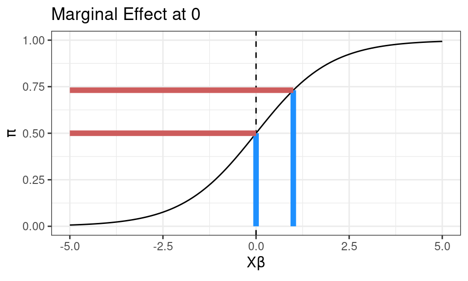

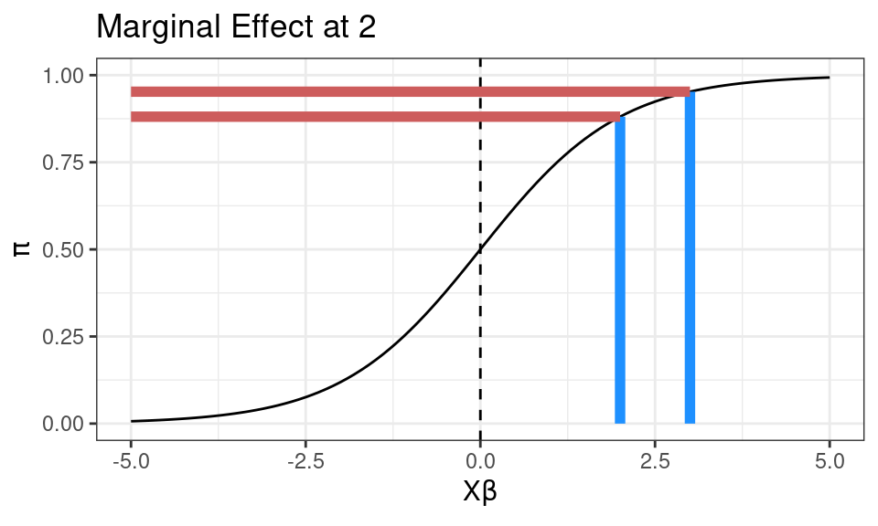

# Transformed quantities

- We have $\hat{\beta}$, but in the propensity score case, we really want $\hat{\pi_i} = Pr(D_i = 1 | X_i)$
  - Just apply the inverse link to get the quantity we want

  $$\hat{\pi_i} = \frac{1}{1 + \text{exp}(-X_i^{\prime}\hat{\beta})}$$
- The function of the MLEs is the MLE of the function
  - So $\hat{\pi_i}$ is consistent for the true propensity scores (under our modeling assumptions)
- But what if we want to do inference on $\hat{\pi_i}$ or obtain a confidence interval?
  - How do we obtain $\text{Var}(\hat{\pi_i}) = \text{Var}(g(\hat{\beta}))$?

# Delta method

- We know $Var(\hat{\beta})$
  - Asymptotically, it’s the inverse Fisher Information or the inverse negative Hessian of the log-likelihood.
- To get $Var(g(\hat{\beta}))$, let’s start with a first-order Taylor approximation around the true value $\beta$

  $$g(\hat{\beta}) \approx g(\beta) + [\nabla g(\beta)^{\prime}](\hat{\beta} - \beta)$$
- Take the variance

  $$Var(g(\hat{\beta})) \approx Var\bigg(g(\beta) + [\nabla g(\beta)^{\prime}](\hat{\beta} - \beta)\bigg)$$
- Expand the sum

  $$Var(g(\hat{\beta})) \approx Var\bigg(g(\beta) + [\nabla g(\beta)^{\prime}]\hat{\beta} - [\nabla g(\beta)^{\prime}]\beta\bigg)$$

# Delta method

- Variance of a constant is zero

  $$Var(g(\hat{\beta})) \approx Var\bigg([\nabla g(\beta)^{\prime}]\hat{\beta}\bigg)$$
- Pull out and “square” the constant. We now get an expression in terms of our original variance-covariance matrix

  $$Var(g(\hat{\beta})) \approx [\nabla g(\beta)^{\prime}]Var(\hat{\beta})[\nabla g(\beta)]$$
- This approximation is exact asymptotically (the higher-order terms of the Taylor polynomial go to zero)
  - Use the usual plug-in estimator for the the gradient at the MLE

# Example: Propensity Score

- Let’s determine the propensity of receiving treatment for a patient at the median covariate values

```r
X_medians <- apply(X_mat, 2, median)
X_medians
```

```
(Intercept)       stent      height      female    diabetic     acutemi
          1           1         173           0           0           0
   ejecfrac    ves1proc
         55           1
```

- Construct our prediction function

```r
pred_prob <- function(beta, X){
  return(1/(1 + exp(-X%*%beta)))
}
pred_median <- pred_prob(coef(logit_mle), X_medians)
pred_median
```

```
      [,1]
[1,] 0.696
```

# Example: Propensity Score

- We could solve for the gradient in terms of $\beta$ analytically, but there are plenty of convenient functions that will do this numerically

```r
pred_prob_gradient <- numericGradient(pred_prob,
                                      t0 = coef(logit_mle),
                                      X = X_medians)
```

- Applying the delta method

```r
pred_prob_var <- pred_prob_gradient%*%logit_vcov%*%t(pred_prob_gradient) # R treats vectors as row-vectors not column vectors
```

- Making our 95% asymptotic CI for $\hat{\pi}(X)$

```r
c(pred_median - abs(qnorm(.025))*sqrt(pred_prob_var),
  pred_median + abs(qnorm(.025))*sqrt(pred_prob_var))
```

```
[1] 0.643 0.749
```

# `marginaleffects`

- The `marginaleffects` R package provides a straightforward implementation of the delta method for a lot of transformed quantities
  - e.g. the marginal change in the **probability of** $Y=1$ for a one-unit change in $X$
- `avg_predictions()` will calculate point estimates + CIs for the expected outcome just like we did above!
- `avg_comparisons()` will do the implied “marginal effects” for a unit change in $X$ given a set baseline.

```r
marginaleffects::avg_predictions(logit_Rglm, newdata = "median")
```

```
 Estimate Std. Error    z Pr(>|z|)     S 2.5 % 97.5 %
    0.696     0.0264 26.3   <0.001 504.8 0.644  0.748

Type: response
```

```r
marginaleffects::avg_comparisons(logit_Rglm, newdata ="median")
```

```
     Term Contrast Estimate Std. Error     z Pr(>|z|)    S    2.5 %    97.5 %
 acutemi     1 - 0  0.18779    0.03225  5.82   <0.001 27.4  0.12459  2.51e-01
 diabetic    1 - 0 -0.09218    0.04010 -2.30   0.0215  5.5 -0.17077 -1.36e-02
 ejecfrac    +1    -0.00314    0.00161 -1.95   0.0509  4.3 -0.00629  1.18e-05
 female      1 - 0 -0.08081    0.04747 -1.70   0.0887  3.5 -0.17386  1.22e-02
 height      +1    -0.00326    0.00199 -1.64   0.1011  3.3 -0.00716  6.38e-04
 stent       1 - 0  0.13255    0.03549  3.73   <0.001 12.4  0.06299  2.02e-01
 ves1proc    +1     0.13451    0.02352  5.72   <0.001 26.5  0.08841  1.81e-01

Type: response
```

# “Monte Carlo” Delta Method

- Alternatively, we could approximate the (asymptotic) sampling distribution of $\hat{\pi}$ by:
  1. Sampling from the known asymptotic distribution of $\hat{\beta}$
  2. Passing each sampled $\beta$ through to our function $\pi = g(\beta)$
  3. Taking the variance of the simulated $\pi$s
- With many independent samples, this will get arbitrarily close to the true sampling variance of $\hat{\pi}$
  - King, Tomz and Wittenberg (2000) is essentially this idea
- Note that this is **not** bootstrapping.
  - We’re using our existing estimator of $\widehat{Var(\hat{\beta})}$
  - Rather it’s doing a “monte carlo” simulation instead of the delta method – no need to take derivatives!

# “Monte Carlo” Delta Method

- Let’s try it:

```r
set.seed(60637)
sim_betas <- MASS::mvrnorm(n=1e5, mu = coef(logit_mle), Sigma = logit_vcov)
sim_pi <- apply(sim_betas, 1, function(x) pred_prob(x, X=X_medians))
```

- How close are we?

```r
c(pred_median - abs(qnorm(.025))*sd(sim_pi),
  pred_median + abs(qnorm(.025))*sd(sim_pi))
```

```
[1] 0.643 0.749
```

# “Latent variables” and logit

# Latent variables

- Another common way of formulating discrete outcome regressions is in terms of an unobserved continuous “latent” variable and an observation mechanism.
  - Instead of putting a distribution on $Y_i$, we put one on an unobserved $Y_i^*$
  - $Y_i$ is some function of $Y_i^*$ (usually an indicator function of some sort)
- For the logistic regression

$$Y_i = \mathbb{1}(Y_i^* \ge 0)$$
$$Y_i^* = X_i^{\prime}\beta + \epsilon_i$$
$$\epsilon_i \sim \text{Logistic}(0, 1)$$

- The Logistic distribution is parameterized in terms of a “location” (mean) $\mu$ and a “scale” parameter $s>0$.
  - For $\mu = 0$, $s= 1$ we have the “standard” logistic

$$P(\epsilon_i < x) = \frac{1}{1 + \exp(-x)}$$

# Latent variables

- So what’s $E[Y_i|X_i] = Pr(Y_i = 1|X_i)$?

$$Pr(Y_i = 1|X_i) = Pr(Y_i^* \ge 0) = Pr(\epsilon_i < X_i^{\prime}\beta) = \frac{1}{1 + \exp(-X_i^{\prime}\beta)}$$

- We can write the **probit** similarly, defining the error distribution as

$$\epsilon_i \sim \text{Normal}(0, 1)$$

- And by extension, the probability $Pr(Y_i|X_i)$

$$Pr(Y_i = 1|X_i) = Pr(Y_i^* \ge 0) = Pr(\epsilon_i < X_i^{\prime}\beta) = \Phi(X_i^{\prime}\beta)$$

# Latent variables

- We can visualize this as an integral over the density of the random “error” $\epsilon_i$

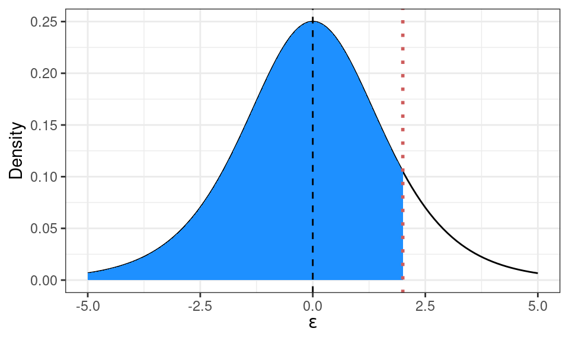

# Latent variables

- Same thing for a probit

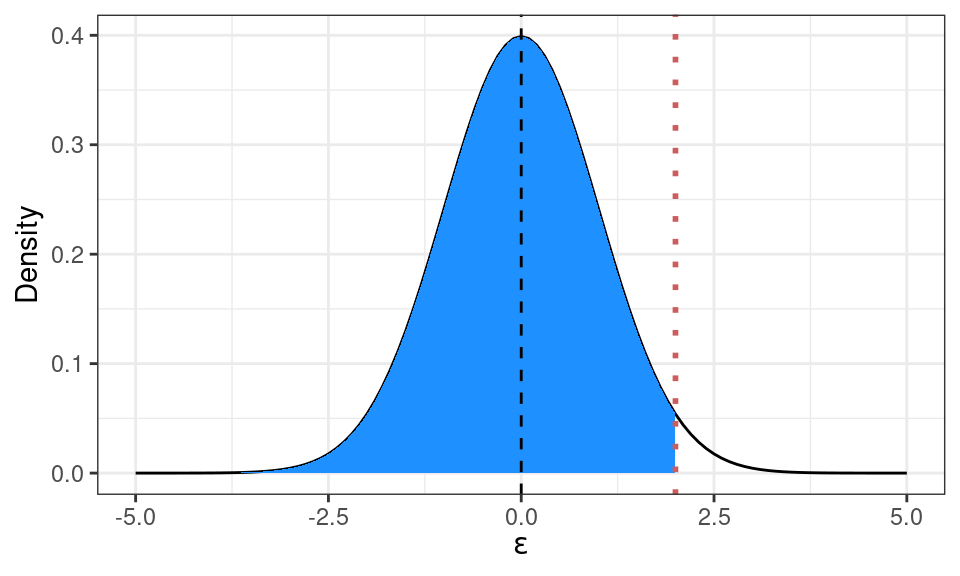

# Ordinal logit

- Using the latent variable formulation lets us extend the binary outcomes to logit to outcomes with multiple discrete levels.
- For example, consider an “ordinal” response variable
  - (e.g.) a likert scale (1 = “strongly disagree”, 3 = “neutral”, 5 = “strongly agree”)
- The responses are *ordered* but the intervals between them do not have any meaning.
  - A popular modeling technique with an ordinal $Y$ is to treat it as an expression of a latent variable

# Ordinal logit

- In an *ordered logit* model, an ordinal outcome $Y$ with $L$ unique, ordered values $Y \in \{1, 2, 3, \dotsc L\}$ is a function of a latent variable and a set of $L-1$ cutpoints $\kappa$

$$Y_i = \begin{cases}1 &\text{if } Y_i^* \le \kappa_1 \\
2 &\text{if } \kappa_1 < Y_i^* \le \kappa_2\\
3 &\text{if } \kappa_2 < Y_i^* \le \kappa_3\\
\vdots &\\
L &\text{if } Y_i^* > \kappa_{L-1}\end{cases}$$

- We still assume $Y_i^*$ has a logistic distribution

$$Y_i^* = X_i^{\prime}\beta + \epsilon_i$$

$$\epsilon_i \sim \text{Logistic}(0, 1)$$

# Ordinal logit

- To estimate the model, we now have to estimate both the $\beta$ parameters and the $\kappa$ parameters
  - Note we omit the intercept from our $X_i$ - the $\kappa$ parameters are essentially the “intercepts” for each boundary between the choices
- How does the model map changes in the latent variable to changes in probability?

$$Pr(Y_i = 1) = Pr(Y_i^* \le \kappa_1) = Pr(\epsilon_i \le \kappa_1 - X_i^{\prime}\beta)$$
$$Pr(Y_i = 2) = Pr(Y_i = 2 \cup Y_i = 1) - Pr(Y_i = 1) = Pr(Y_i^* \le \kappa_2) - Pr(Y_i^* \le \kappa_1)$$
$$Pr(Y_i = 3) = Pr(Y_i = 3 \cup Y_i = 2 \cup Y_i = 1) - Pr(Y_i = 2 \cup Y_i = 1) = Pr(Y_i^* \le \kappa_3) - Pr(Y_i^* \le \kappa_2)$$

# Ordinal logit

- Let’s think in terms of the distribution of $Y_i^*$ and the cut-points for a case with $L=3$. For $X_i^{\prime}\beta = 0$:

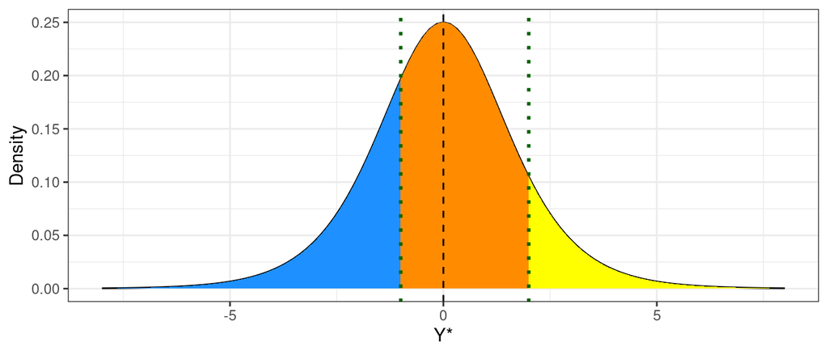

# Ordinal logit

- Shifting the mean of $Y^*$ up by 3:

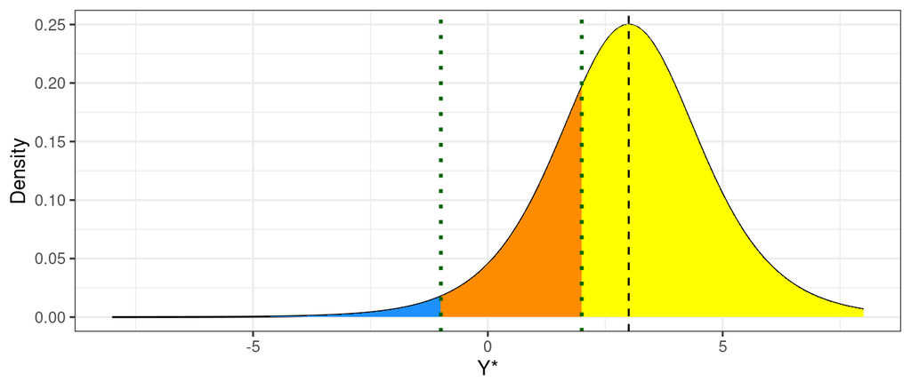

# Ordinal logit

- This structural mapping from $Y^*$ to $P(Y_i = l)$ is not trivial - it encodes a particular assumption about how these probabilities relate to one another.
- Referred to as the **proportional odds** assumption

$$\log\left(\frac{Pr(Y_i \le l)}{1 - Pr(Y_i \le l)}\right) = \kappa_l - X_i^{\prime}\beta$$

- **Intuitively** – The $\beta$ parameters are shared across all the possible outcome levels. Information about whether someone responds “strongly agree” *also* tells us something about how likely they would be to respond specifically to “agree”, “neutral”, “disagree”, and “strongly disagree”
  - Not trivial if there’s non-monotonicity or heterogeneous effects.
  - Be careful with these models!

# Multinomial logit

- In a setting with multiple **unordered** outcomes, the natural extension of the logit regression is the **multinomial** logit
  - Here, the latent-variable formulation is particularly helpful.
- Suppose we have an outcome with $K$ unordered levels (e.g. “choices”). Define latent variables $Y_{ik}^*$ for the $K-1$ categories $k = 2, 3, \dotsc K$
  - For identification, we set one category to be the “baseline” by anchoring the coefficients to zero $\beta_1 = 0$

  $$\begin{align*}Y_{i2}^* &= X_i^{\prime}\beta_2 + \epsilon_{i2}\\
  Y_{i3}^* &= X_i^{\prime}\beta_3 + \epsilon_{i3}\\
  &\vdots \\
  Y_{iK}^* &= X_i^{\prime}\beta_K + \epsilon_{iK}\end{align*}$$
- The probability of observing the choice $Y_{i} = k^*$ is the probability that the $k^*$th “latent variable” is greater than all of the others.

  $$Pr(Y_i = k^*) = Pr(\text{max}\{Y^*_{i1}, Y^*_{i2}, \dotsc Y^*_{iK}\} = Y^*_{ik^*})$$

# Multinomial logit

- It turns out that if the error terms $\epsilon_{ik}$ have i.i.d. “Type I extreme value” distributions, we can write the choice probabilities in closed form.

  $$Pr(Y_i = k^*) = \frac{\exp(X_i^{\prime}\beta_{k^*})}{\sum_{k=1}^K \exp(X_i^{\prime}\beta_{k})}$$
- This is sometimes refered to as the “softmax” function in machine learning
- **Note**: With a normalized “baseline” category 1, we can write this equivalently as:

  $$Pr(Y_i = k^*) = \frac{\exp(X_i^{\prime}\beta_{k^*})}{1 + \sum_{k=2}^K \exp(X_i^{\prime}\beta_{k})}$$

# Example: Appointer Affiliation Bias

- **Puig and Strezhnev (2017)** ran a survey experiment on a group of international arbitration experts to see how manipulating the appointing party affected their decisionmaking in a hypothetical vignette
  - Respondents were given a hypothetical dispute and asked to determine who should pay the legal costs
  - Three options: **Loser pays all**, **Loser pays some**, **Both sides split**

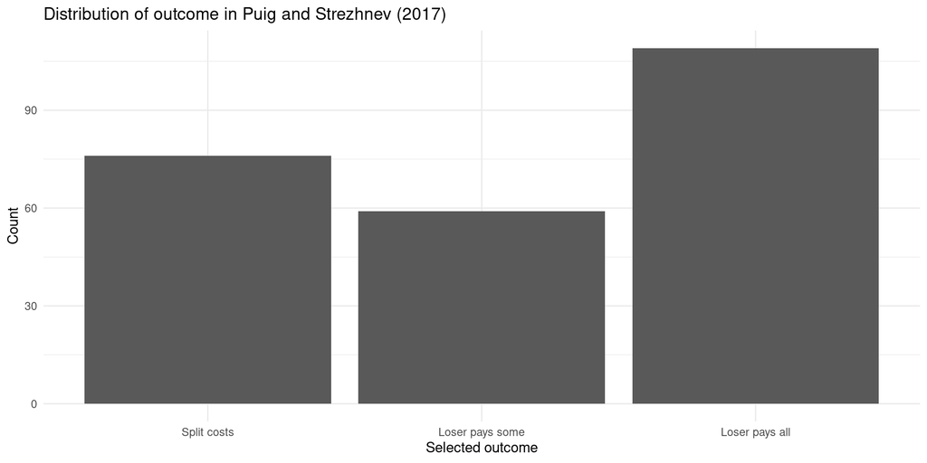

# Example: Appointer Affiliation Bias

- It would seem like an ordinal logit regression would be appropriate here - three category discrete outcome with a clear ordering
  - Implemented in the `ordinal` package

```r
ordered_logit <- ordinal::clm(isReimbursementFolded_Factor ~ isAppointerSide, data=study1_complete %>%
                       filter(isAppointerSide == "Appointed by Winner"|isAppointerSide == "Appointed by Loser"))
```

```r
summary(ordered_logit)
```

```
formula: isReimbursementFolded_Factor ~ isAppointerSide
data:
study1_complete %>% filter(isAppointerSide == "Appointed by Winner" | isAppointerSide == "Appointed by Loser")

 link  threshold nobs logLik  AIC    niter max.grad cond.H
 logit flexible  123  -128.28 262.57 5(0)  2.98e-13 1.5e+01

Coefficients:
                                   Estimate Std. Error z value Pr(>|z|)
isAppointerSideAppointed by Winner    0.411      0.340    1.21     0.23

Threshold coefficients:
                               Estimate Std. Error z value
Split costs|Loser pays some      -0.672      0.262   -2.56
Loser pays some|Loser pays all    0.302      0.256    1.18
```

# Example: Appointer Affiliation Bias

- The model implies that arbitrators appointed by the winning party shift mostly from **splitting the costs** to making the loser pay for **everything**
  - But is this real or an artifact of the proportional odds assumption? Is there a “constant effect” on the latent variable scale?

```r
marginaleffects::avg_comparisons(ordered_logit)
```

```
           Group Estimate Std. Error     z Pr(>|z|)   S   2.5 % 97.5 %
 Loser pays all    0.1022     0.0839  1.22    0.223 2.2 -0.0623 0.2667
 Loser pays some  -0.0170     0.0156 -1.09    0.275 1.9 -0.0476 0.0135
 Split costs      -0.0851     0.0706 -1.21    0.228 2.1 -0.2235 0.0532

Term: isAppointerSide
Type: prob
Comparison: Appointed by Winner - Appointed by Loser
```

# Example: Appointer Affiliation Bias

- Compare with **multinomial logit** (which in this case is equivalent to OLS for each category since we’re using a fully-saturated regression)

```r
multinom_logit <- nnet::multinom(isReimbursementFolded_Factor ~ isAppointerSide, data=study1_complete %>%
                       filter(isAppointerSide == "Appointed by Winner"|isAppointerSide == "Appointed by Loser"))
```

```r
marginaleffects::avg_comparisons(multinom_logit)
```

```
           Group Estimate Std. Error      z Pr(>|z|)   S    2.5 %  97.5 %
 Loser pays all     0.180     0.0892  2.015   0.0439 4.5  0.00494  0.3546
 Loser pays some   -0.197     0.0773 -2.544   0.0110 6.5 -0.34834 -0.0452
 Split costs        0.017     0.0826  0.205   0.8372 0.3 -0.14498  0.1789

Term: isAppointerSide
Type: probs
Comparison: Appointed by Winner - Appointed by Loser
```

# Survival models

# Survival models

- Often we have outcome data that is measured as the “time-to-event”
  - From the medical literature, this is often the number of days before a patient suffers some adverse event (e.g. death).
  - But lots of other applications (e.g. time to treaty ratification)
- Assume we observe N i.i.d. event times $T_1, T_2, \dotsc, T_n$
- Define the “survival function”

  $$S(t) = Pr(T > t) = 1 - F(t)$$
- We’ll also often work with the “hazard” or the “instantaneous” probability of an event happening *given* that it has not yet occurred

  $$h(t) = \underset{\Delta t \to 0}{\lim} \frac{P(t < T_i \le t + \Delta t | T_i > t)}{\Delta t} = \frac{f(t)}{S(t)} = \frac{f(t)}{1-F(t)}$$
- **Intuitively**: Given that I know that an event has not occurred until $t$, what is the probability that it will immediately occur next!

# Survival models

- We’ll also define the cumulative hazard

  $$H(t) = \int_{0}^{t} h(u)du = \int_0^{t} \frac{f(u)}{S(u)} du = -\log(S(t))$$

# Non-parametric approach

- The easiest way to estimate $S(t) = 1 - F(t)$ is to just plug in $\hat{F(t)}$ - our empirical CDF in the sample
  - At any given value $t$, how many events occur *after* $t$
- **Problem**: This doesn’t address *censoring* of observations – sometimes we stop observing a unit at time $t^*$ rather than observing an actual event.
  - We know that $T_i > t^*$ but not what $T_i$ actually equals
- Let $C = \{C_1, C_2, \dotsc, C_n\}$ denote the **censoring indicator**
  - If $C_i = 1$, then the observation is *censored*, the observed value $t$ only gives us information on $T_i > t$ as opposed to $T_i = t$.
  - Crucially, we assume that censoring is “uninformative”
- One approach to constructing a non-parametric estimator of the survival function *under censoring* is the **Kaplan-Meier** estimator.

# Kaplan-Meier Estimator

- Start by arranging the possible event times from $0 < t_{(1)} < t_{(2)} < t_{(3)} < t_{(4)}, \dotsc, < t_{(n)}$
  - Suppose $t$ is after $t_{(j)}$ and before $t_{(j+1)}$. We can write the survival function in terms of conditional probabilities:

  $$S(t) = Pr(T_i > t | T_i > t_{(j)}) \times Pr(T_i > t_{(j)} | T_i > t_{(j-1)}) \times \dotsc \times Pr(T_i > t_{(2)} | T_i > t_{(1)}) \times Pr(T_i > t_{(1)})$$
- The **Kaplan-Meier** estimator $\hat{S(t)}$ can be understood as a “plug-in” estimator for each of these probabilities.

  $$\hat{S}(t) = \prod_{j: t_{(j)} \le t} \bigg(1 - \frac{d_j}{r_j} \bigg)$$
- $d_j$ denotes the number of units that experience an event at time $t_{(j)}$
- $r_j$ is the number of units that are still in the risk set up to time $j$
  - Units drop out of the risk set $r$ over time by either experiencing an event or being censored

# Kaplan-Meier Estimator

- **Intuition**: Consider one of the terms in the product. Using the definition of conditional probability:

  $$Pr(T_i > t_{(j)} | T_i > t_{(j-1)}) = 1 - Pr(T_i < t_{(j)}|T_i > t_{j-1}) = 1 - \frac{Pr(T_i \le t_{(j)}, T_i > t_{(j-1)})}{Pr(T_i > t_{(j-1)})}$$
- In the numerator, our “plug-in” estimator is just the share of units that have events occurring at $t_{(j)}$.
- In the denominator we have the share of units that we know for sure are still “active” in the interval after $t_{(j-1)}$
- Hence our plug-in estimator:

  $$\widehat{Pr(T_i > t_{(j)} | T_i > t_{(j-1)})} = 1 - \frac{d_j}{r_j}$$
- Taking the product across all of the $j$ where $t_{(j)} < t$ yields the Kaplan-Meier estimator.

# Illustration: Lung Cancer

- Let’s look at a sample dataset from the `survival` R package on survival times for patients with advanced lung cancer.

```r
library(survival)
data(cancer, package="survival")
as_tibble(lung)
```

```
# A tibble: 228 × 10
    inst  time status   age   sex ph.ecog ph.karno pat.karno meal.cal wt.loss
   <dbl> <dbl>  <dbl> <dbl> <dbl>   <dbl>    <dbl>     <dbl>    <dbl>   <dbl>
 1     3   306      2    74     1       1       90       100     1175      NA
 2     3   455      2    68     1       0       90        90     1225      15
 3     3  1010      1    56     1       0       90        90       NA      15
 4     5   210      2    57     1       1       90        60     1150      11
 5     1   883      2    60     1       0      100        90       NA       0
 6    12  1022      1    74     1       1       50        80      513       0
 7     7   310      2    68     2       2       70        60      384      10
 8    11   361      2    71     2       2       60        80      538       1
 9     1   218      2    53     1       1       70        80      825      16
10     7   166      2    61     1       2       70        70      271      34
# ℹ 218 more rows
```

- We want to estimate $S(t | \text{Sex} = \text{Male})$ and $S(t | \text{Sex} = \text{Female})$

# Illustration: Lung Cancer

- In the `survival` package, we need to define a “survival” outcome in terms of the event time and the censoring indicator

```r
surv_model <- survfit(Surv(time, status) ~ 1, data=lung)
```

# Illustration: Lung Cancer

- Plot the curve for the sample as a whole

```r
plot(surv_model, xlab="Survival Time", conf.int=T, ylab="Survival Rate", mark.time=TRUE)
```

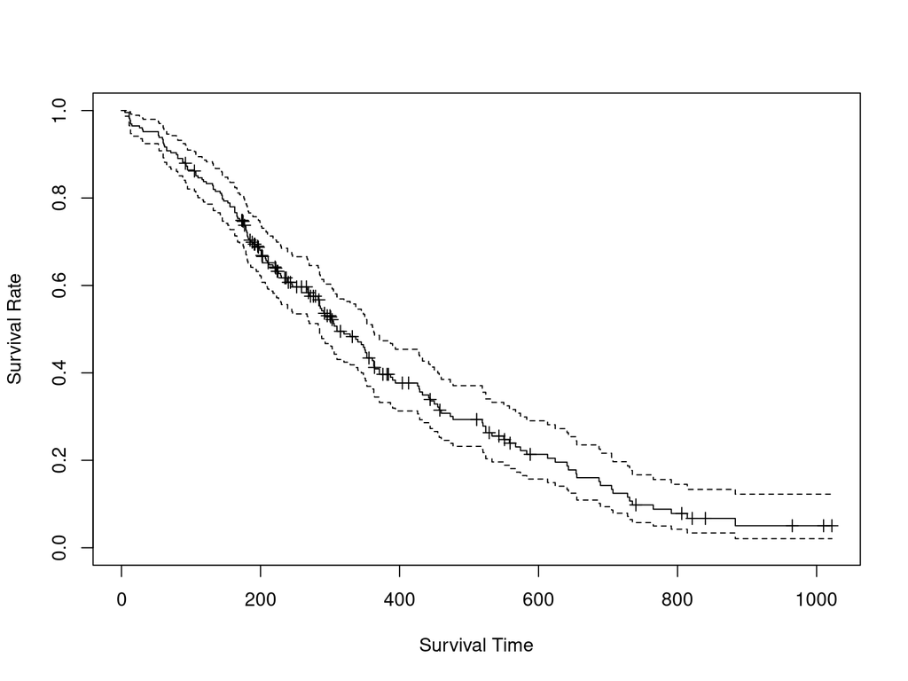

# Illustration: Lung Cancer

- Now let’s do this for gender

```r
surv_model_sex <- survfit(Surv(time, status) ~ I(sex==2), data=lung)
```

# Illustration: Lung Cancer

- Plot separate curves for men and women

```r
plot(surv_model_sex, col=c("indianred", "dodgerblue"), xlab="Survival Time", conf.int=T, ylab="Survival Rate", mark.time=T)
legend(750, .9, c("Male", "Female"), col=c("indianred", "dodgerblue"), lwd=2, bty='n')
```

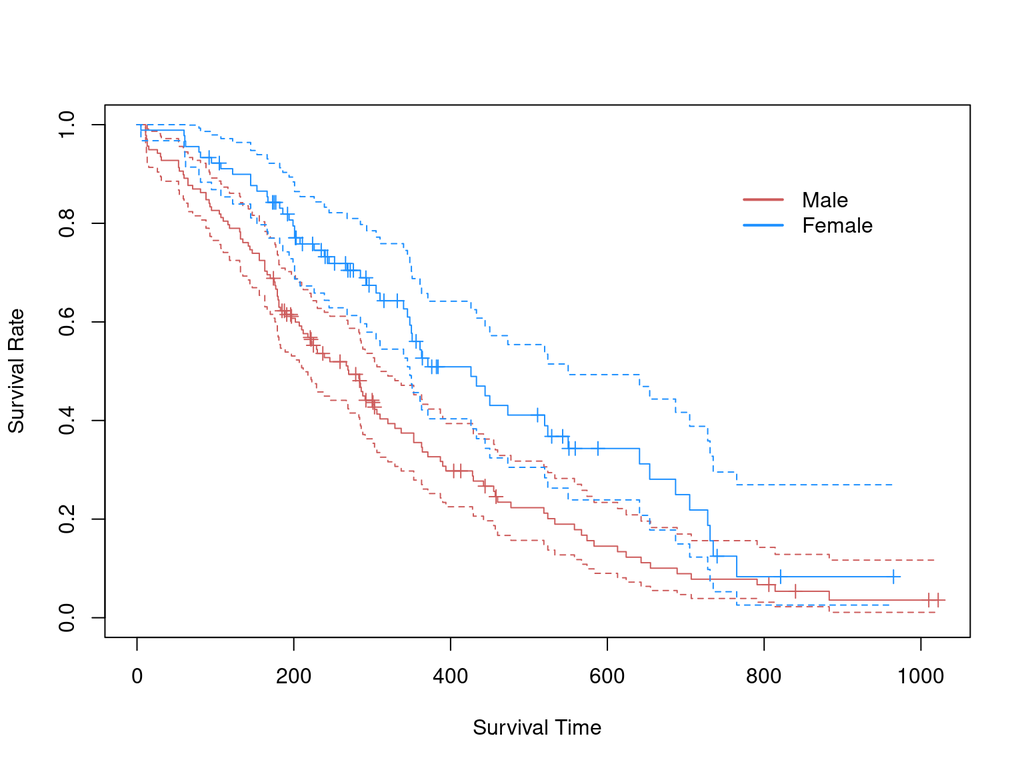

# Parametric inference

- When we want to model the survival function using covariates, we run into a clear constraint using purely non-parametric methods – with continuous covariates, we may only have one observation that has a unique covariate value
  - Splitting the sample and constructing separate K-M curves quickly becomes infeasible.
- We may want to assume a **model** for the event time. We can write that density in terms of the *hazard* and the *survival* function

  $$f(t) = h(t)S(t)$$
- Note that by the definition of the cumulative hazard $H(t) = - \log(S(t))$ and $S(t) = \exp(-H(t))$, so

  $$f(t) = h(t)\exp(-H(t))$$

# Parametric inference

- Depending on the assumptions we make about the nature of the hazard, we can obtain different distributions for $f(t)$.
  - In the simplest case, lets assume that the hazard does not vary over time: $h(t) = \lambda$. $\lambda > 0$
  - And the cumulative hazard is $H(t) = \int_{0}^{t} \lambda du = \lambda t$
- This yields the **exponential distribution**

  $$f(t) = \lambda \exp(-\lambda t)$$

# Exponential Model

- The mean of $T_i \sim \text{Exponential}(\lambda)$ is $E[T_i] = \frac{1}{\lambda}$. We’ll often reparameterize the mean as $\theta$, yielding a density of

  $$f(t) = \frac{1}{\theta} \exp\bigg(-\frac{1}{\theta} t\bigg)$$
- $\theta$ is strictly greater than $0$, so we’ll use a log-link to incorporate the covariates:

  $$\log(E[Y_i | X_i] = \log(\theta_i) = X_i^{\prime}\beta$$
- Alternatively, we can write

  $$E[Y_i | X_i] = \exp(X_i^{\prime}\beta)$$
- Note that the constant hazard assumption is a strong one – the exponential distribution is “memoryless” in that knowing that a unit has survived up until time $t$ tells you nothing about its instantenous probability of failure.
  - More flexible distributions like the Weibull allow for a time-varying hazard.

# Exponential Model

- We can interpret changes in the linear predictor in terms of changes in the hazard since

$$h(t) = \frac{1}{\theta_i} = \frac{1}{\exp(X_i^{\prime}\beta)}$$

- Increases in the linear predictor reduce the hazard.
- This also lets us write down the survival function

$$S(t) = \exp\bigg(- \frac{1}{\exp(X_i^{\prime}\beta)}t \bigg)$$

# Application

- Let’s compare our parametric fit to the non-parametric Kaplan-Meier estimates

```r
exp_model_sex <- survreg(Surv(time, status) ~ I(sex==2), dist="exponential", data=lung) # sex = 2 is a dummy variable for female
```

- Get the survival curves for men and women

```r
exp_surv_men <- function(x) pexp(x, rate = 1/exp(coef(exp_model_sex)%*%c(1,0)), lower.tail = F)
exp_surv_women <- function(x) pexp(x, rate = 1/exp(coef(exp_model_sex)%*%c(1,1)), lower.tail=F)
```

# Application

- Overlay the exponential survival curves on the Kaplan-Meier estimates

```r
plot(surv_model_sex, col=c("indianred", "dodgerblue"), xlab="Survival Time", conf.int=T, ylab="Survival Rate", mark.time=T)
legend(750, .9, c("Male", "Female"), col=c("indianred", "dodgerblue"), lwd=2, bty='n')
curve(exp_surv_men, from = 0, to = 1000, lwd=2, col="indianred", add=T)
curve(exp_surv_women, from = 0, to = 1000, lwd=2, col="dodgerblue", add=T)
```

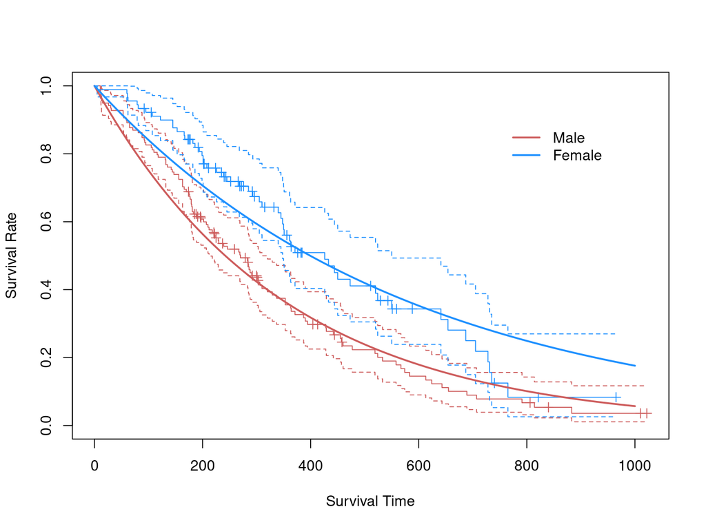

# Semi-parametric

- You’ll notice that the fit is okay, but there is some discrepancy
  - This is because the hazard appears to be **time-varying**.
  - You can see a kind of “s-curve” which the exponential by construction cannot capture.
- Other parametric models allow for more flexibility in the hazard rate’s evolution over time
  - For example, the **Weibull** model, which adds an additional shape parameter to the hazard to allow it to vary over time actually fits the data quite well!
- But suppose that we want to make very minimal assumptions about the structure of the hazard function – can we still estimate the relationship between covariates and the hazard?

# Cox Proportional Hazards

- The **Cox proportional hazards model** assumes that covariates enter the hazard log-linearly, but the baseline hazard is unspecified

$$h_i(t) = h_0(t)\exp(X_i^{\prime}\beta)$$

- $h_0(t)$ is the unknown baseline hazard function.
- Note that while the baseline hazard is not explicitly identified, the ratio of the hazards of two observations $i$ and $j$ at time $t$ **does not depend on the baseline**

  $$\frac{h_i(t)}{h_j(t)} = \frac{\exp(X_i^{\prime}\beta)}{\exp(X_j^{\prime}\beta)}$$
- The model is **semi-parametric** in that some components are left entirely unspecified…
  - … but others are not – we assume that the covariates act **proportionally** on the hazard irrespective of time.

# Cox Proportional Hazards

- The model is estimated by maximizing a **partial likelihood**
  - We observe event time $Y_i$ - assume no ties
- The individual partial likelihood is

  $$L_i(\beta) = \frac{\exp(X_i^{\prime}\beta)}{\sum_{k; Y_k \ge Y_i} \exp(X_k^{\prime}\beta)}$$
- **Intuitively**: The denominator contains the hazards of all observations in the **risk set** at the event time $Y_i$
- Then the full likelihood is just the product over all the individual partial likelihoods

  $$L(\beta) = \prod_{i=1}^N \frac{\exp(X_i^{\prime}\beta)}{\sum_{k; Y_k \ge Y_i} \exp(X_k^{\prime}\beta)}$$

# Application

- What does the Cox fit look like

```r
cox_model_sex <- coxph(Surv(time, status) ~ I(sex==2), data=lung) # sex = 2 is a dummy variable for female
print(cox_model_sex)
```

```
Call:
coxph(formula = Surv(time, status) ~ I(sex == 2), data = lung)

                coef exp(coef) se(coef)  z     p
I(sex == 2)TRUE -0.5       0.6      0.2 -3 0.001

Likelihood ratio test=11  on 1 df, p=0.001
n= 228, number of events= 165
```

- Note that we **don’t get** an estimate of the hazard because the baseline is left unspecified
  - If we want to plot survival curves, we’ll need some estimate of $h_0$ using another method (like Kaplan-Meier)

# Application

- Calculate the baseline hazard via Kaplan-Meier and overlay the Cox predicted hazards for men and women

```r
plot(survfit(cox_model_sex, newdata = data.frame(sex=c(1,2))), col=c("indianred", "dodgerblue"), xlab="Survival Time", conf.int=T, ylab="Survival Rate", mark.time=T)
```

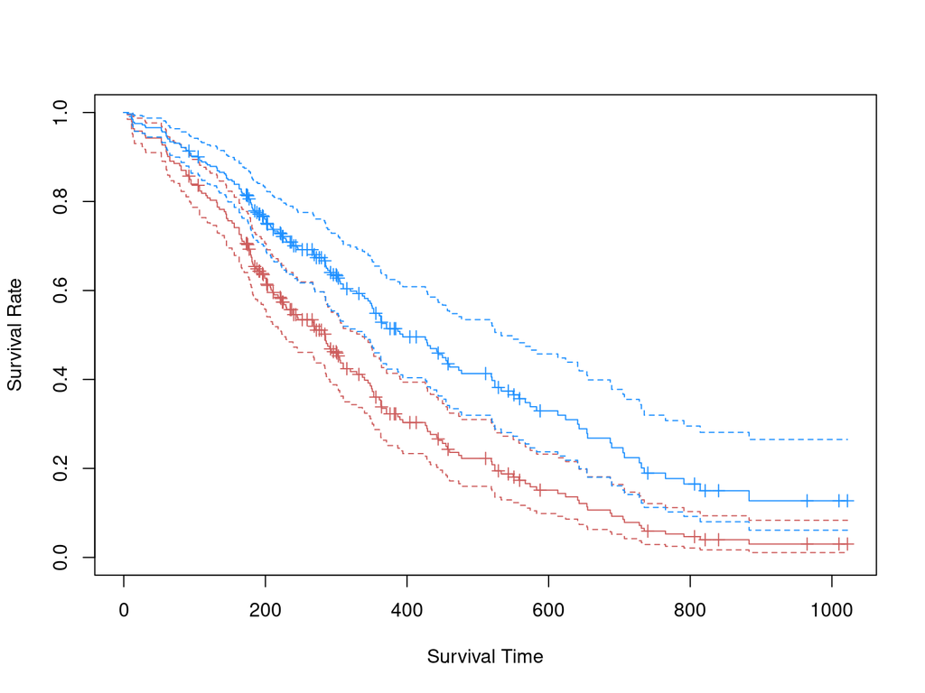